# PS4

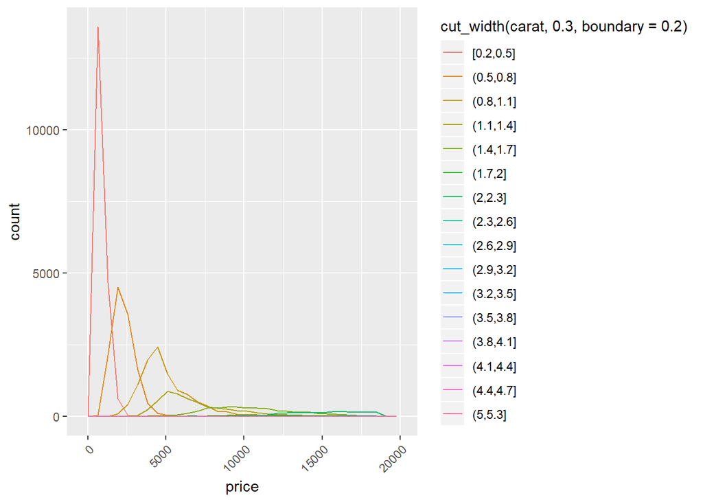

```r
ggplot(diamonds) +
  geom_freqpoly(mapping = aes(x = price, color = cut_width(carat, 0.3, boundary = 0.2))) +
  theme(axis.text.x = element_text(angle = 45, hjust = 1))
```

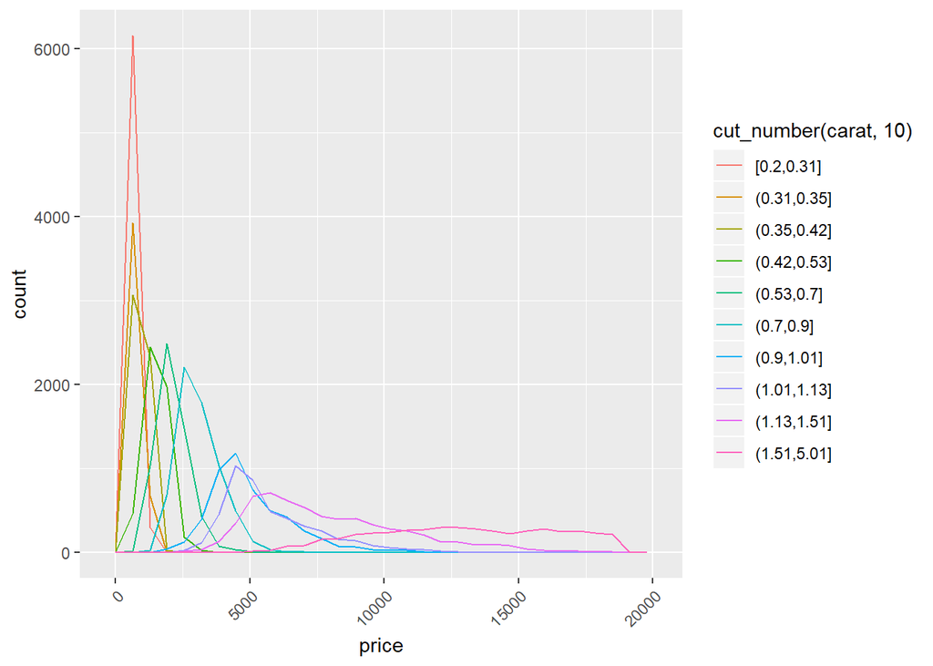

```r
ggplot(diamonds) +
  geom_freqpoly(mapping = aes(x = price, color = cut_number(carat, 10))) +
  theme(axis.text.x = element_text(angle = 45, hjust = 1))
```

b. cut_width() divides carat into bins of width. When using cut_width(), the width of bins is fixed. And when using cut_number(),the plot displays approximately the same number of points in each bin and the widths of bins are very different.

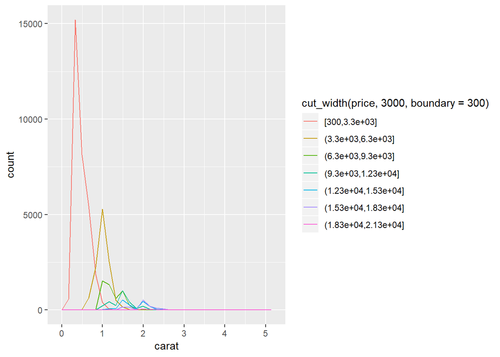

```r
ggplot(diamonds) +
  geom_freqpoly(mapping = aes(x = carat, color = cut_width(price, 3000, boundary = 300)))
```

5. The price distribution of very large diamonds has a surge on price of arround 18000. And the distribution of smaller diamonds has a surge on a farily low price. It is just as expected. Also, for smaller diamonds(carat<2.4), price increases when carat increases. However, for larger diamonds, there is no clear relationship between carat and price. It is also consistent with my espectation. For smaller diamonds, weight is the most important factor in pricing, however it is not for larger diamonds.

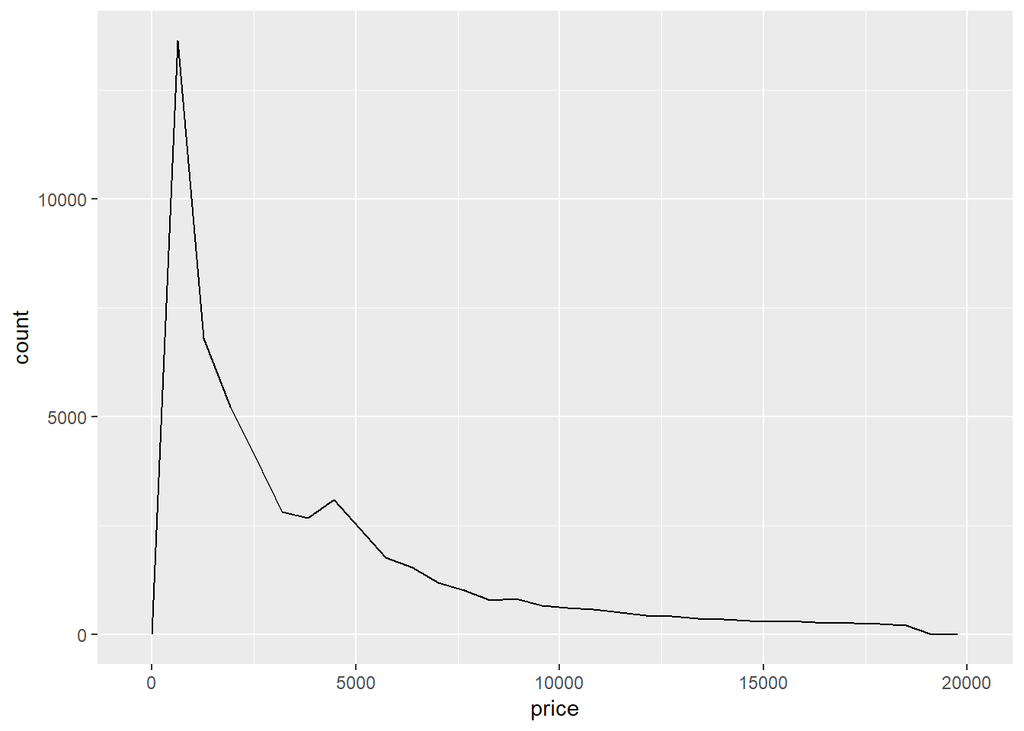

```r
smaller <- diamonds %>%
  filter(carat < 3)
bigger <- diamonds %>%
  filter(carat > 3)
ggplot(smaller)+
  geom_freqpoly(mapping=aes(x=price))
```